# Classification

Jeu de données res.PCA

.

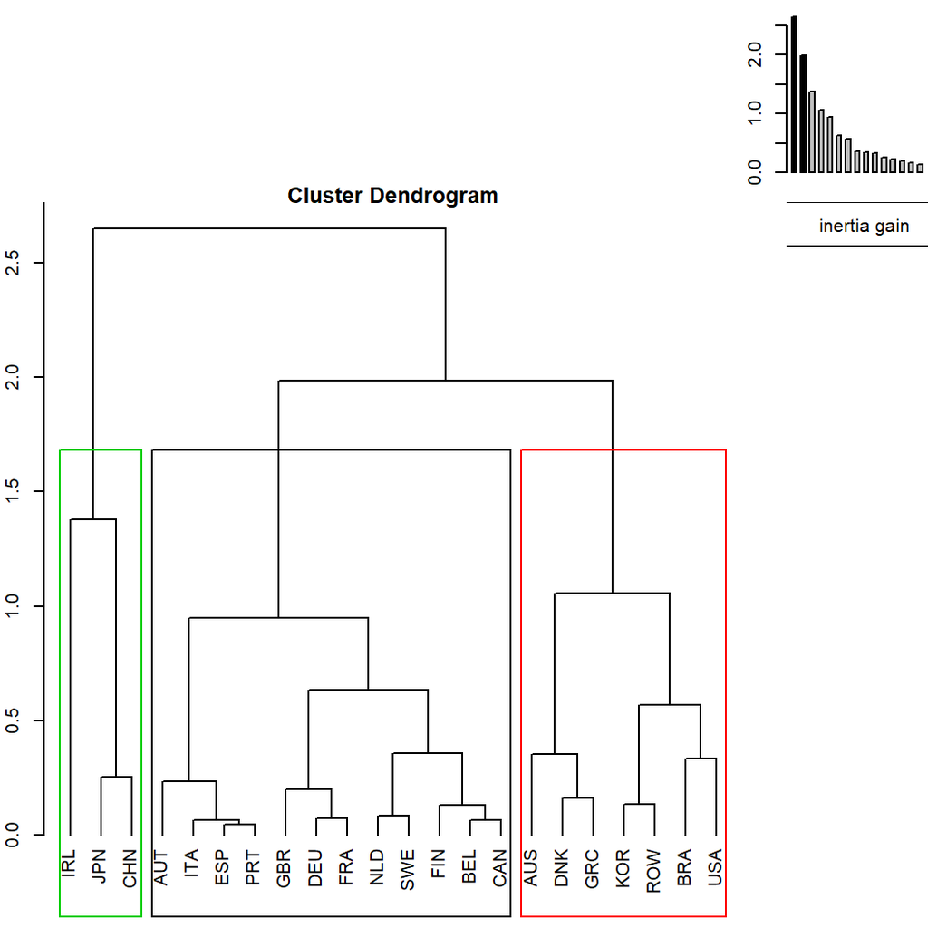

**Figure 1.1 - Arbre hiérarchique.**

La classification réalisée sur les individus fait apparaître 3 classes.

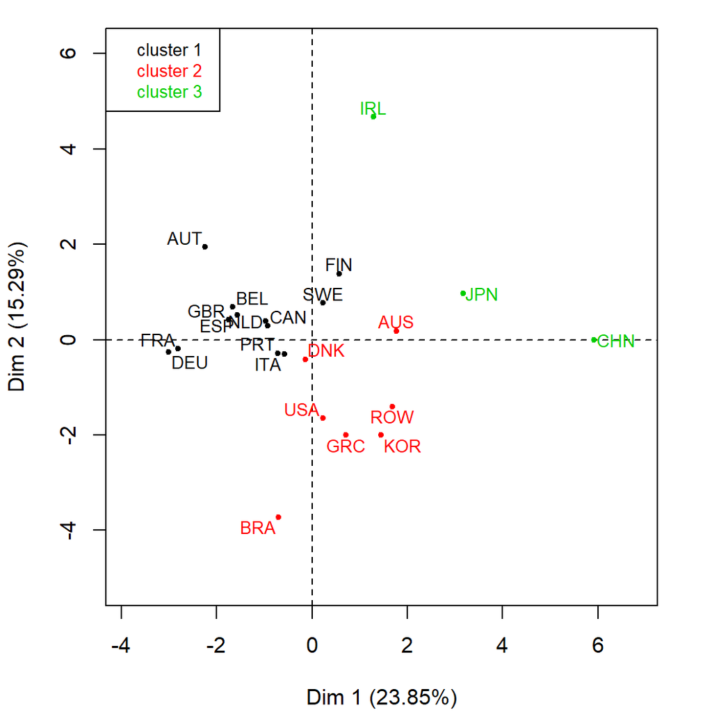

**Figure 1.2 - Classification Ascendante Hiérachique des individus.**

La **classe 1** est composée d’individus tels que *AUT*, *DEU* et *FRA*. Ce groupe est caractérisé par :

- de fortes valeurs pour les variables *C5_Bwd*, *FZ_Fwd* et *C4_Bwd* (de la plus extrême à la moins extrême).
- de faibles valeurs pour les variables *IZ_Bwd*, *HZ_Bwd*, *OQ_Bwd* et *FZ_Bwd* (de la plus extrême à la moins extrême).

La **classe 2** est composée d’individus tels que *BRA*, *GRC*, *KOR*, *ROW* et *USA*. Ce groupe est caractérisé par :

- de fortes valeurs pour la variable *HZ_Bwd*.
- de faibles valeurs pour la variable *DE_Bwd*.

La **classe 3** est composée d’individus tels que *CHN*, *IRL* et *JPN*. Ce groupe est caractérisé par :

- de fortes valeurs pour les variables *JZ_Bwd*, *MN_Bwd*, *RU_Fwd*, *KZ_Fwd* et *IZ_Fwd* (de la plus extrême à la moins extrême).
- de faibles valeurs pour les variables *C5_Bwd*, *C1_Bwd*, *C2_Bwd*, *C5_Fwd*, *C4_Bwd* et *FZ_Fwd* (de la plus extrême à la moins extrême).

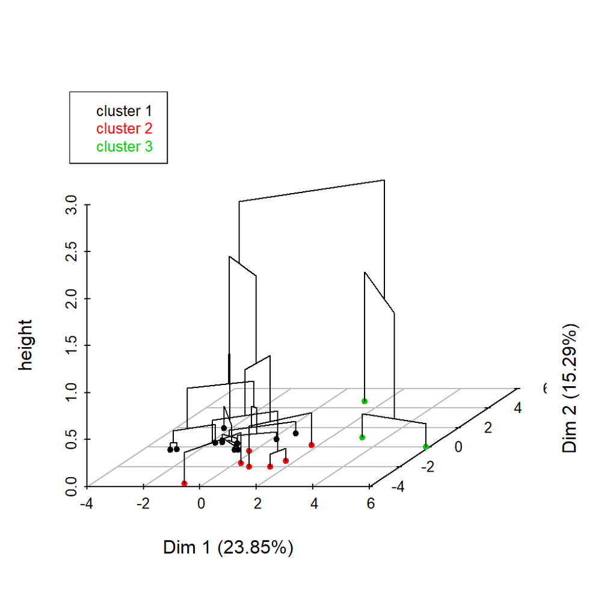

**Figure 1.3 - Arbre hiérarchique sur le plan factoriel.**

The hierarchical tree can be drawn on the factorial map with the individuals colored according to their clusters.